# 3. Actividad Evaluable 3

Grupo 4: Guillermo Cadavid, Pau Pous

2025-01-25

## Análisis de logs de servidor usando R

### Obtención y carga de los datos

Una vez leído el fichero, hemos obtenido los siguientes datos:

| Nombre | Tipo | Descripción |
| --- | --- | --- |
| ip | Character | Dirección IP o URL de la petición |
| timestamp | DateTime | Fecha y hora en que se realiza la petición |
| peticion | Character | La petición, con el método, recurso y protocolo utilizado |
| codigo | Character | Código de la respuesta de la petición |
| bytes | Numeric | Tamaño en bytes de la petición |

A continuación, una muestra (`head()`) de los datos obtenidos.

| ip | timestamp | peticion | codigo | bytes |
| --- | --- | --- | --- | --- |
| 141.243.1.172 | [29:23:53:25] | GET /Software.html HTTP/1.0 | 200 | 1497 |
| query2.lycos.cs.cmu.edu | [29:23:53:36] | GET /Consumer.html HTTP/1.0 | 200 | 1325 |
| tanuki.twics.com | [29:23:53:53] | GET /News.html HTTP/1.0 | 200 | 1014 |
| wpbfl2-45.gate.net | [29:23:54:15] | GET / HTTP/1.0 | 200 | 4889 |
| wpbfl2-45.gate.net | [29:23:54:16] | GET /icons/circle_logo_small.gif HTTP/1.0 | 200 | 2624 |
| wpbfl2-45.gate.net | [29:23:54:18] | GET /logos/small_gopher.gif HTTP/1.0 | 200 | 935 |

### Limpieza de los datos

A continuación, se muestran los datos una vez limpiados y transformados, incluyendo nuevas columnas útiles para el análisis.

#### Columnas añadidas tras la limpieza

| Nombre | Tipo | Descripción |
| --- | --- | --- |
| ip | Character | Dirección IP o URL de la petición |
| timestamp | DateTime/POSIXct | Fecha y hora en que se realiza la petición |
| numeric_timestamp | Numeric | Fecha y hora en formato numérico |
| peticion | Character | Petición completa con método, recurso y protocolo |
| metodo | Factor | Método utilizado en la petición: GET, POST, DELETE, HEAD |
| recurso | Character | Contenido solicitado por la petición |
| protocolo | Factor | Protocolo utilizado en la petición (HTTP/1.0) |
| bytes | Numeric | Tamaño en bytes de la petición |
| is_error | Factor | Indica si la respuesta tiene un código de error |
| is_image | Factor | Indica si el recurso solicitado es una imagen |
| domain_extension | Factor | Extensión del dominio, o “none” si es una dirección IP |
| domain | Factor | Dominio de la URL, o “none” si es una dirección IP |

#### Muestra de los datos limpiados

Una vez aplicados los pasos de limpieza, aquí se presenta una muestra (`head()`) de los datos procesados.

| ip | timestamp | peticion | metodo | recurso | protocolo | codigo | bytes | numeric_timestamp | is_error | is_image | domain_extension | domain |
| --- | --- | --- | --- | --- | --- | --- | --- | --- | --- | --- | --- | --- |
| 141.243.1.172 | 2024-11-29 23:53:25 | GET /Software.html HTTP/1.0 | GET | /Software.html | HTTP/1.0 | 200 | 1497 | 1732924405 | FALSE | FALSE | none | none |
| query2.lycos.cs.cmu.edu | 2024-11-29 23:53:36 | GET /Consumer.html HTTP/1.0 | GET | /Consumer.html | HTTP/1.0 | 200 | 1325 | 1732924416 | FALSE | FALSE | edu | cmu.edu |
| tanuki.twics.com | 2024-11-29 23:53:53 | GET /News.html HTTP/1.0 | GET | /News.html | HTTP/1.0 | 200 | 1014 | 1732924433 | FALSE | FALSE | com | twics.com |
| wpbfl2-45.gate.net | 2024-11-29 23:54:15 | GET / HTTP/1.0 | GET | / | HTTP/1.0 | 200 | 4889 | 1732924455 | FALSE | FALSE | net | gate.net |
| wpbfl2-45.gate.net | 2024-11-29 23:54:16 | GET /icons/circle_logo_small.gif HTTP/1.0 | GET | /icons/circle_logo_small.gif | HTTP/1.0 | 200 | 2624 | 1732924456 | FALSE | TRUE | net | gate.net |
| wpbfl2-45.gate.net | 2024-11-29 23:54:18 | GET /logos/small_gopher.gif HTTP/1.0 | GET | /logos/small_gopher.gif | HTTP/1.0 | 200 | 935 | 1732924458 | FALSE | TRUE | net | gate.net |

### Exploracion de Datos

#### Total usuarios unicos

El total de usuarios únicos se divide en dos categorías:

- Usuarios sin errores: Aquellos cuyas peticiones no generaron errores.
- Usuarios con errores: Aquellos que han generado al menos un error.

| Total usuarios unicos | Usuarios con errores | Usuarios sin error |
| --- | --- | --- |
| 2319 | 638 | 1681 |

#### Breakdown usuarios unicos por errores

Listado de los códigos de error recibidos y el número único de usuarios que experimentaron dichos errores.

| Codigo del error | Numero de usuarios unicos |
| --- | --- |
| 302 | 176 |
| 304 | 505 |
| 500 | 29 |

### Analisis de Datos

Análisis de la frecuencia de los métodos utilizados en las peticiones.

#### Frecuencia de Peticiones por Método

| Metodfo | Frequencia |
| --- | --- |
| GET | 40961 |
| POST | 1350 |
| HEAD | 106 |

#### Frecuencia de Peticiones por Método (Solo Imágenes)

| Metodo | Frequencia |
| --- | --- |
| GET | 21627 |
| HEAD | 56 |

### Visualizacion de Datos

#### Gráfico 1: Distribución de Bytes por Extensión de Dominio

Este gráfico muestra la distribución del total de bytes descargados en función de las extensiones de dominio. Solo se consideran las peticiones con código de respuesta correcto (`200`).

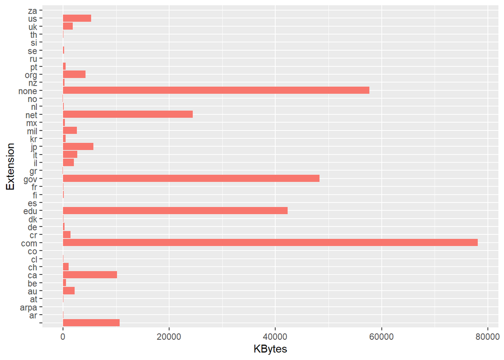

#### Gráfico 2: Comparación de Códigos de Respuesta

Este gráfico representa la distribución de los diferentes códigos de respuesta devueltos por el servidor.

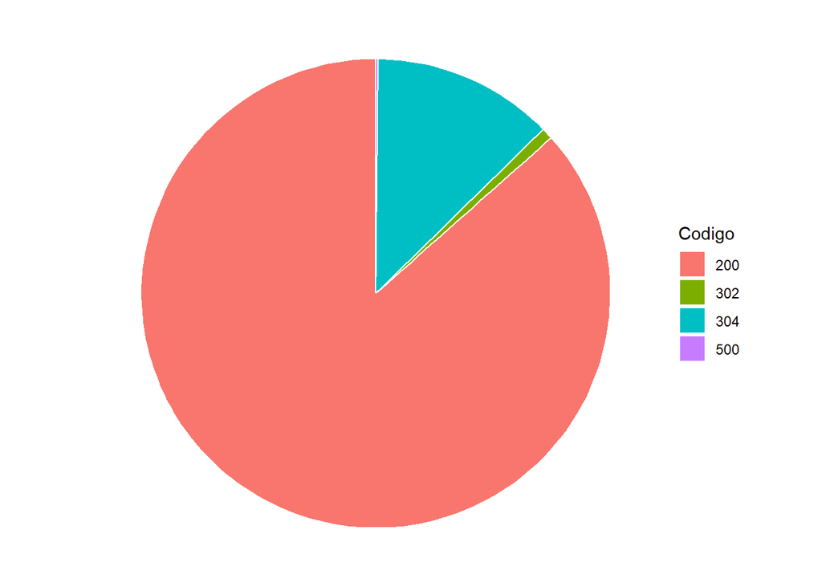

#### Gráfico 3: Peticiones a lo Largo del Tiempo

Visualización del número de peticiones realizadas en intervalos de tiempo específicos, agrupadas por minuto.

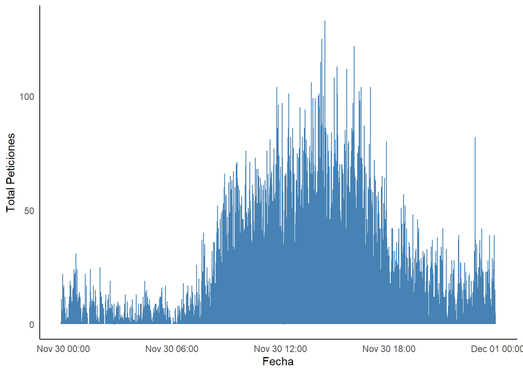

## Clustering de Datos

Se realizó un análisis de clustering utilizando el algoritmo de `k-means` para clasificar las peticiones del servidor en base a características como: - Tamaño en bytes. - Método utilizado. - Si la petición contiene un error. - Si la petición solicita imágenes.

Los resultados se visualizan en gráficos que muestran cómo se agrupan las peticiones en función de diferentes combinaciones de características.

### Grafico 1: Tamaño de peticiones vs Timestamp

Este gráfico muestra cómo se agrupan las peticiones en función de su tamaño y el timestamp de la petición.

[figure not shown]

### Gráfico 2: Tamaño de peticiones vs Recurso

Este gráfico analiza cómo las peticiones se agrupan en función del recurso solicitado y su tamaño.

[figure not shown]

### Gráfico 3: Timestamp vs Recurso

Este gráfico muestra la relación entre el timestamp y los recursos solicitados, agrupados por clusters.

[figure not shown]

### Gráfico 4: Analisis por Dominio

Se agrupan los dominios en función del total de bytes transferidos, número de peticiones, errores y solicitudes de imágenes.

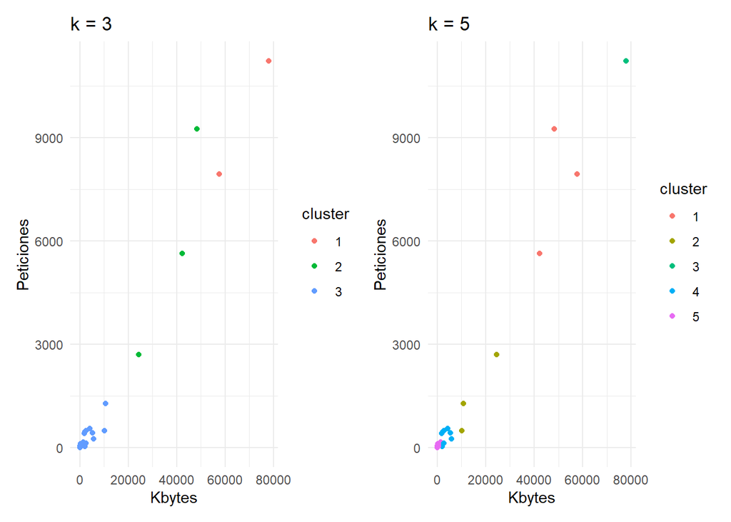